# Data analysis Morphological masked priming experiment on L1-ITA, L2-ENG bilingual speakers/readers

Paper titled *Masked morphological priming tracks the development of a fully mature lexical system in L2* - Submitted to JML in June 2019

Eva Viviani

Davide Crepaldi

03 June 2020

This script takes preprocessed data and produces all the analyses that are reported in the paper.

# clean WS, set WD and load data

Set your local working directory. This should be (and is assumed to be in the rest of the code) the highest point in your local folder:

```r
localGitDir <- 'C:/Users/eva_v/Documents/GitHub/M2-maskedprimingBilinguals'
setwd(localGitDir);
```

This script works on the outcome of preProcessing.R, which you can upload here:

```r
read.table(paste(localGitDir, '/preprocessedData.txt', sep = ''), header = T, sep='\t', dec='.',
           colClasses=c("prime"="factor",
                        "target"="factor",
                        "lexicality"="factor",
                        "morphType"="factor",
                        "relatedness"="factor",
                        "aoa3.context"="factor",
                        "aoa4.contextMultling"="factor",
                        "aoa6.otherLang"="factor",
                        "language"="factor",
                         "gender"="factor",
                         "handedness"="factor"
                        )) -> masterFile;

head(masterFile);
summary(masterFile);
```

Load packages and create functions

```r
library(ggplot2);
library(rms);
library(effects);
library(plyr);
library(corrplot);
library(lme4);
library(ggpubr);

inv <- function(x) {-1000/x};
```

GLMMs takes a lot of time to run, depending on the machine and the dataset. We have saved the models that successfully converged in a folder.

```r
df <- list.files(paste(localGitDir, "/LMMs and GLMMs/", sep = ""));
length(df);
```

```
## [1] 45
```

```r
for (i in 1:length(df)){
  gsub(".rds$", "", df[i]) -> id
  assign(id, data.frame())
  readRDS(paste(localGitDir, "/LMMs and GLMMs/", df[i],sep = "")) -> temp
  assign(paste0(id), temp)
};
rm(temp)
```

# Participants

```r
temp <- unique(masterFile[,c('subject','age','gender','handedness')]);
```

age, education and handedness:

```r
summary(temp)
```

```
##     subject           age           gender   handedness
##  Min.   : 1.00   Min.   :18.00   Female:56   Left :11
##  1st Qu.:21.00   1st Qu.:22.00   Male  :28   Right:73
##  Median :41.50   Median :24.00
##  Mean   :41.65   Mean   :24.32
##  3rd Qu.:62.25   3rd Qu.:26.00
##  Max.   :84.00   Max.   :34.00
```

# Stimuli

```r
temp <- unique(masterFile[,c('target','prime','lexicality','morphType','relatedness','freqTarget','freqPrime','lengthTarget','lengthPrime','nTarget','nPrime','language')]);
summary(temp);
```

```
##      target          prime       lexicality  morphType  relatedness
##  abito  :  2   abbazia  :  1   nonword:300   op  :200   ctrl:450
##  acid   :  2   ability  :  1   word   :600   or  :200   rel :450
##  acre   :  2   abitudine:  1                 tr  :200
##  adopt  :  2   absence  :  1                 NA's:300
##  again  :  2   abstain  :  1
##  agree  :  2   abstract :  1
##  (Other):888   (Other)  :894
##    freqTarget      freqPrime      lengthTarget   lengthPrime
##  Min.   :1.367   Min.   :1.170   Min.   :3.00   Min.   : 5.000
##  1st Qu.:3.382   1st Qu.:2.630   1st Qu.:4.00   1st Qu.: 6.000
##  Median :3.913   Median :3.155   Median :5.00   Median : 7.000
##  Mean   :3.875   Mean   :3.233   Mean   :4.92   Mean   : 7.423
##  3rd Qu.:4.446   3rd Qu.:3.860   3rd Qu.:5.00   3rd Qu.: 8.000
##  Max.   :5.840   Max.   :6.290   Max.   :8.00   Max.   :13.000
##  NA's   :300     NA's   :2
##     nTarget          nPrime       language
##  Min.   : 0.00   Min.   : 0.000   eng:450
##  1st Qu.: 5.00   1st Qu.: 1.000   ita:450
##  Median :10.00   Median : 2.000
##  Mean   :13.43   Mean   : 3.131
##  3rd Qu.:19.00   3rd Qu.: 4.000
##  Max.   :54.00   Max.   :36.000
##
```

## Target features, ITA

Frequency of the targets, mean and sd

```
##   morphType freqTarget
## 1        op    3.63032
## 2        or    3.94728
## 3        tr    3.96898
```

```
##   morphType freqTarget
## 1        op  0.8779550
## 2        or  0.8523670
## 3        tr  0.6718303
```

Length of the targets, mean and sd

```
##   morphType lengthTarget
## 1        op         5.08
## 2        or         4.94
## 3        tr         5.16
```

```
##   morphType lengthTarget
## 1        op    0.8490042
## 2        or    0.8855746
## 3        tr    1.0704478
```

Coltheart’s N, mean and sd

```
##   morphType nTarget
## 1        op   20.12
## 2        or   21.56
## 3        tr   18.14
```

```
##   morphType  nTarget
## 1        op 11.91492
## 2        or 13.45274
## 3        tr 11.32265
```

## Prime features, ITA

Frequency of the primes, mean and sd

```
##   relatedness morphType freqPrime
## 1        ctrl        op  3.095800
## 2         rel        op  3.157653
## 3        ctrl        or  3.198040
## 4         rel        or  3.228920
## 5        ctrl        tr  2.913200
## 6         rel        tr  2.923460
```

```
##   relatedness morphType freqPrime
## 1        ctrl        op 0.8518056
## 2         rel        op 0.7863899
## 3        ctrl        or 0.6784778
## 4         rel        or 0.6984253
## 5        ctrl        tr 0.6843910
## 6         rel        tr 0.8404621
```

Length of the primes, mean and sd

```
##   relatedness morphType lengthPrime
## 1        ctrl        op        7.96
## 2         rel        op        7.96
## 3        ctrl        or        7.52
## 4         rel        or        7.52
## 5        ctrl        tr        7.70
## 6         rel        tr        7.70
```

```
##   relatedness morphType lengthPrime
## 1        ctrl        op    1.211509
## 2         rel        op    1.211509
## 3        ctrl        or    1.182181
## 4         rel        or    1.182181
## 5        ctrl        tr    1.249490
## 6         rel        tr    1.249490
```

Coltheart’s N, mean and sd

```
##   relatedness morphType nPrime
## 1        ctrl        op   3.84
## 2         rel        op   3.52
## 3        ctrl        or   3.54
## 4         rel        or   4.24
## 5        ctrl        tr   3.82
## 6         rel        tr   3.62
```

```
##   relatedness morphType   nPrime
## 1        ctrl        op 2.937165
## 2         rel        op 2.628261
## 3        ctrl        or 2.525058
## 4         rel        or 6.169576
## 5        ctrl        tr 2.973969
## 6         rel        tr 2.905940
```

# Outliers trimming, ITA

```r
subset(masterFile, language=="ita") -> masterFileIta;
```

The following code generates target and sbj means and SDs, and the outlier graphs in the file ‘ita.jpg’

```r
sbj.id <- masterFileIta$subject;
acc <- masterFileIta$accuracy;
lexicality <- tolower(masterFileIta$lexicality);
target <- masterFileIta$target;
rt <- masterFileIta$rt;

source(paste(localGitDir, "/tools/diagnostics.R", sep=''));
outlierGraphStore <- 'Desktop';
diagnostics.f(rt = rt, acc = acc, sbj.id = sbj.id, target = target, lexicality = lexicality, paste(outlierGraphStore, "ita", sep=""));
rm(outlierGraphStore, rt, target, lexicality, acc, sbj.id);
```

Based on the graphs in ‘ita.jpg’: we exclude **sbj 2** and **31** for an abnormal error rate on nonwords (<80%); and target words **GUANO**, **UGGIA** and **VELLO** with abnormally low accuracy (<60%). **sbj 15** is excluded because s/he reported having seen the primes.

Individual RTs distribution seems fine, but let’s check the tails more carefully:

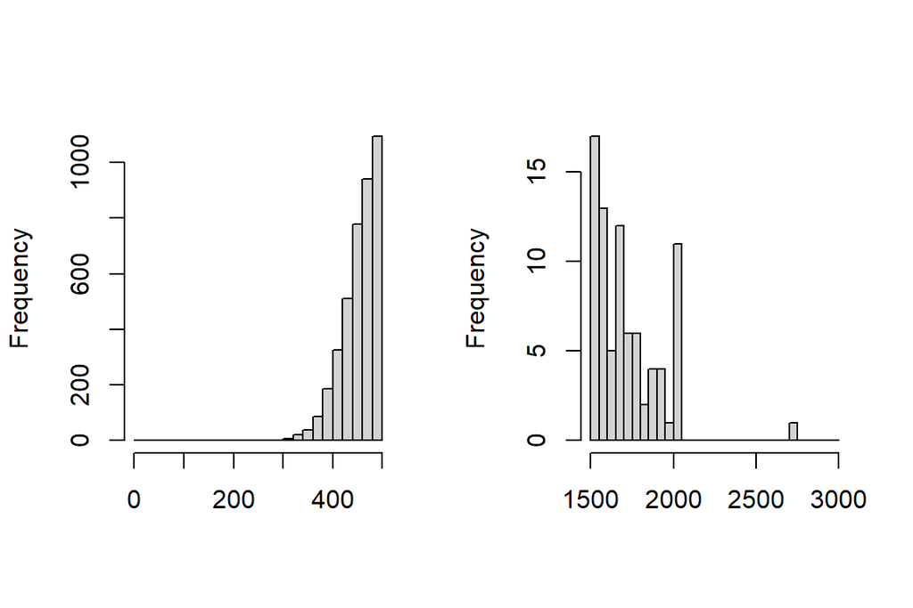

```r
par(mfrow=c(1,2))
hist(masterFileIta$rt[masterFileIta$rt<500], breaks=seq(0,500,20), main = " ", xlab = " ");
hist(masterFileIta$rt[masterFileIta$rt>1500], breaks=seq(1500,3000,50), main = " ", xlab = " ");
```

```r
par(mfrow=c(1,1))
```

```r
dataItaAcc <- subset(masterFileIta, lexicality=="word");
dataItaTemp <- subset(dataItaAcc, accuracy==1);
dataIta <- subset(dataItaTemp, rt>280 & rt<2000 & subject!=15 & subject!=2 & subject!=31 & target!= "guano" & target!= "uggia" & target!= "vello");
```

- Number of datapoints trimmed: 526
- Percentage of datapoints trimmed: 4.56%
- Number of datapoints left: 11009

Summary of the dataset trimmed:

```r
summary(dataIta)
```

```
##     subject           age           gender     handedness     trialCount
##  Min.   : 1.00   Min.   :18.00   Female:7362   Left :1284   Min.   :  1.0
##  1st Qu.:22.00   1st Qu.:22.00   Male  :3647   Right:9725   1st Qu.: 77.0
##  Median :43.00   Median :24.00                              Median :150.0
##  Mean   :42.19   Mean   :24.44                              Mean   :150.5
##  3rd Qu.:62.00   3rd Qu.:27.00                              3rd Qu.:225.0
##  Max.   :84.00   Max.   :34.00                              Max.   :300.0
##
##        rt              resp    trialType           lexicality    morphType
##  Min.   : 284.0   Min.   :2   Length:11009       nonword:    0   op:3717
##  1st Qu.: 499.0   1st Qu.:2   Class :character   word   :11009   or:3621
##  Median : 564.0   Median :2   Mode  :character                   tr:3671
##  Mean   : 594.5   Mean   :2
##  3rd Qu.: 652.0   3rd Qu.:2
##  Max.   :1960.0   Max.   :2
##
##      target            prime       relatedness   freqTarget      freqPrime
##  abito  :   78   abitudine:   39   ctrl:5498   Min.   :1.367   Min.   :1.191
##  ballo  :   78   albergo  :   39   rel :5511   1st Qu.:3.435   1st Qu.:2.562
##  banca  :   78   alleanza :   39               Median :3.989   Median :3.039
##  cambio :   78   areola   :   39               Mean   :3.915   Mean   :3.093
##  corda  :   78   ballatoio:   39               3rd Qu.:4.450   3rd Qu.:3.606
##  corte  :   78   bancario :   39               Max.   :5.671   Max.   :4.909
##  (Other):10541   (Other)  :10775                               NA's   :37
##   lengthTarget    lengthPrime        nTarget          nPrime
##  Min.   :3.000   Min.   : 5.000   Min.   : 0.00   Min.   : 0.000
##  1st Qu.:4.000   1st Qu.: 7.000   1st Qu.:11.00   1st Qu.: 2.000
##  Median :5.000   Median : 8.000   Median :18.00   Median : 3.000
##  Mean   :5.064   Mean   : 7.756   Mean   :20.13   Mean   : 3.723
##  3rd Qu.:6.000   3rd Qu.: 9.000   3rd Qu.:30.00   3rd Qu.: 5.000
##  Max.   :8.000   Max.   :10.000   Max.   :47.00   Max.   :36.000
##
##    rotation         language      oscTarget        accuracy phonemicFluency
##  Length:11009       eng:    0   Min.   : NA     Min.   :1   Min.   : 0.00
##  Class :character   ita:11009   1st Qu.: NA     1st Qu.:1   1st Qu.:17.00
##  Mode  :character               Median : NA     Median :1   Median :23.00
##                                 Mean   :NaN     Mean   :1   Mean   :22.52
##                                 3rd Qu.: NA     3rd Qu.:1   3rd Qu.:27.00
##                                 Max.   : NA     Max.   :1   Max.   :45.00
##                                 NA's   :11009
```

[output cut: 9 more lines]

```
##  Min.   : 8.00   Min.   :1.000     Min.   : 0.000   Min.   :1.00
##  1st Qu.:14.00   1st Qu.:3.000     1st Qu.: 6.000   1st Qu.:2.00
##  Median :15.00   Median :5.000     Median : 6.000   Median :3.00
##  Mean   :15.28   Mean   :4.593     Mean   : 6.544   Mean   :3.12
##  3rd Qu.:17.00   3rd Qu.:6.000     3rd Qu.: 8.000   3rd Qu.:4.00
##  Max.   :19.00   Max.   :6.000     Max.   :15.000   Max.   :5.00
##
##  aoa3.context  aoa4.contextMultling aoa5.selfRatedProf aoa6.otherLang
##  home  :1433   no :8446             Min.   :1.00       no :2673
##  school:9576   yes:2563             1st Qu.:3.00       yes:8336
##                                     Median :4.00
##                                     Mean   :3.54
##                                     3rd Qu.:4.00
##                                     Max.   :5.00
##
```

# Outliers trimming, ENG

```r
subset(masterFile, language=="eng") -> masterFileEng;
```

The following code generates target and sbj means and SDs, and the outlier graphs in the file ‘eng.jpg’

```r
outlierGraphStore <- 'Desktop';
sbj.id <- masterFileEng$subject;
acc <- masterFileEng$accuracy;
lexicality <- masterFileEng$lexicality;
lexicality <- tolower(masterFileEng$lexicality);
target <- masterFileEng$target;
rt <- masterFileEng$rt;

diagnostics.f(rt = rt, acc = acc, sbj.id = sbj.id, target = target, lexicality = lexicality, paste(outlierGraphStore, "eng", sep=""));
rm(outlierGraphStore, rt, target, lexicality, acc, sbj.id);
```

**sbj 26** likely confused YES/NO buttons. Let’s check the frequency effect, just to confirm:

```r
cor(masterFileEng[masterFileEng$subject==26 & masterFileEng$lexicality=='word', c('rt','freqTarget')], use = 'pairwise.complete.obs'); #unlikely s/he responded randomly. So, let's fix this:
```

```
##                    rt freqTarget
## rt          1.0000000 -0.2116401
## freqTarget -0.2116401  1.0000000
```

```r
masterFileEng$accuracy[masterFileEng$subject==26] <- car::recode(masterFileEng$accuracy[masterFileEng$subject==26], "1=0;0=1");
```

ok, we can now rerun diagnostics:

```r
outlierGraphStore <- 'Desktop';
sbj.id <- masterFileEng$subject;
acc <- masterFileEng$accuracy;
lexicality <- masterFileEng$lexicality;
lexicality <- tolower(masterFileEng$lexicality);
target <- masterFileEng$target;
rt <- masterFileEng$rt;

diagnostics.f(rt = rt, acc = acc, sbj.id = sbj.id, target = target, lexicality = lexicality, paste(outlierGraphStore, "eng", sep=""));
rm(outlierGraphStore, rt, target, lexicality, acc, sbj.id);
```

Based on the graphs in ‘eng.jpg’: we exclude **sbj 22** for a very atypical performance (average **RT<200ms**). We would exclude no target, even though some of them do elicit bad performance–the distribution is very continuous, no sign of glaring outliers. Plus, this is L2, so low performance is to be expected. **sbj 15** and **43** reported having seen the primes.

Individual RTs distribution seems fine, but let’s check the tails more carefully:

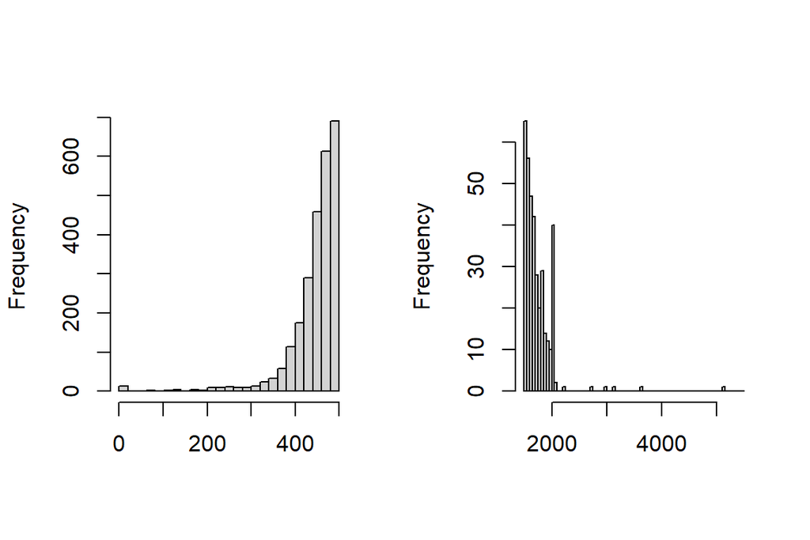

```r
par(mfrow=c(1,2))
hist(masterFileEng$rt[masterFileEng$rt<500], breaks=seq(0,500,20), main = "", xlab = "");
hist(masterFileEng$rt[masterFileEng$rt>1500], breaks=seq(1500,5500,50), main = "", xlab = "");
```

- First graph: very continuous towards zero; perhaps some technical problem with the response box? Weird though, only in English. Anyway, deflection in the curve around 300ms, so let’s cut there.
- Second graph: clear outliers over 2000ms

```r
dataEngAcc <- subset(masterFileEng, lexicality=="word");
dataEngTemp <- subset(dataEngAcc, accuracy==1);
dataEng <- subset(dataEngTemp, rt>300 & rt<2000 & subject!=15 & subject!=22 & subject!=43);
```

- Number of datapoints trimmed: 281
- Percentage of datapoints trimmed: 3.05%
- Number of datapoints left: 8938

Summary of the trimmed dataset:

```r
summary(dataEng);
```

```
##     subject           age           gender     handedness     trialCount
##  Min.   : 1.00   Min.   :18.00   Female:6170   Left : 907   Min.   :  1.0
##  1st Qu.:20.00   1st Qu.:22.00   Male  :2768   Right:8031   1st Qu.: 74.0
##  Median :42.00   Median :24.00                              Median :150.0
##  Mean   :41.76   Mean   :24.19                              Mean   :149.8
##  3rd Qu.:63.00   3rd Qu.:26.00                              3rd Qu.:224.0
##  Max.   :84.00   Max.   :34.00                              Max.   :300.0
##
##        rt              resp        trialType           lexicality   morphType
##  Min.   : 312.0   Min.   :0.000   Length:8938        nonword:   0   op:2946
##  1st Qu.: 544.0   1st Qu.:2.000   Class :character   word   :8938   or:2762
##  Median : 622.0   Median :2.000   Mode  :character                  tr:3230
##  Mean   : 672.1   Mean   :1.986
##  3rd Qu.: 742.0   3rd Qu.:2.000
##  Max.   :1998.0   Max.   :2.000
##
##      target           prime      relatedness   freqTarget      freqPrime
##  again  :  78   against  :  40   ctrl:4388   Min.   :1.650   Min.   :1.170
##  angel  :  78   angelic  :  40   rel :4550   1st Qu.:3.555   1st Qu.:2.820
##  legend :  78   cloudless:  40               Median :4.050   Median :3.410
##  unit   :  78   dreamer  :  40               Mean   :4.058   Mean   :3.472
##  blood  :  77   drunkard :  40               3rd Qu.:4.680   3rd Qu.:4.080
##  fruit  :  77   extract  :  40               Max.   :5.840   Max.   :6.290
##  (Other):8472   (Other)  :8698
##   lengthTarget    lengthPrime        nTarget           nPrime
##  Min.   :3.000   Min.   : 5.000   Min.   : 0.000   Min.   : 0.000
##  1st Qu.:4.000   1st Qu.: 6.000   1st Qu.: 4.000   1st Qu.: 0.000
##  Median :5.000   Median : 7.000   Median : 7.000   Median : 1.000
##  Mean   :4.828   Mean   : 7.215   Mean   : 8.785   Mean   : 2.485
##  3rd Qu.:5.000   3rd Qu.: 8.000   3rd Qu.:12.000   3rd Qu.: 3.000
##  Max.   :7.000   Max.   :13.000   Max.   :44.000   Max.   :24.000
##
##    rotation         language     oscTarget          accuracy phonemicFluency
##  Length:8938        eng:8938   Min.   :-0.0940   Min.   :1   Min.   : 0.00
##  Class :character   ita:   0   1st Qu.: 0.2630   1st Qu.:1   1st Qu.:17.00
##  Mode  :character              Median : 0.6230   Median :1   Median :23.00
##                                Mean   : 0.5767   Mean   :1   Mean   :22.61
##                                3rd Qu.: 0.8990   3rd Qu.:1   3rd Qu.:27.00
##                                Max.   : 1.0000   Max.   :1   Max.   :45.00
##                                NA's   :155
```

[output cut: 9 more lines]

```
##  Min.   : 8.00   Min.   :1.00      Min.   : 0.000   Min.   :1.000
##  1st Qu.:14.00   1st Qu.:3.00      1st Qu.: 6.000   1st Qu.:2.000
##  Median :16.00   Median :5.00      Median : 6.000   Median :3.000
##  Mean   :15.34   Mean   :4.59      Mean   : 6.433   Mean   :3.174
##  3rd Qu.:17.00   3rd Qu.:6.00      3rd Qu.: 8.000   3rd Qu.:4.000
##  Max.   :19.00   Max.   :6.00      Max.   :15.000   Max.   :5.000
##
##  aoa3.context  aoa4.contextMultling aoa5.selfRatedProf aoa6.otherLang
##  home  :1231   no :6811             Min.   :1.000      no :2062
##  school:7707   yes:2127             1st Qu.:3.000      yes:6876
##                                     Median :3.000
##                                     Mean   :3.526
##                                     3rd Qu.:4.000
##                                     Max.   :5.000
##
```

# Raw means

- Mean accuracy ITA: 95%
- Mean RT ITA: 594.51 ms
- Mean accuracy ENG: 76%
- Mean RT ENG: 672.1 ms

Mean RT and sd by relatedness and morphtype - ITA dataset:

```r
aggregate(rt ~ relatedness + morphType, FUN=mean, data=dataIta);
```

```
##   relatedness morphType       rt
## 1        ctrl        op 614.4428
## 2         rel        op 598.8104
## 3        ctrl        or 607.0192
## 4         rel        or 606.5746
## 5        ctrl        tr 589.1723
## 6         rel        tr 551.3402
```

```r
aggregate(rt ~ relatedness + morphType, FUN=sd, data=dataIta);
```

```
##   relatedness morphType       rt
## 1        ctrl        op 150.3067
## 2         rel        op 157.5980
## 3        ctrl        or 145.9696
## 4         rel        or 155.8299
## 5        ctrl        tr 131.0569
## 6         rel        tr 126.2728
```

Mean RT and sd by relatedness and morphtype - ENG dataset:

```r
aggregate(rt ~ relatedness + morphType, FUN=mean, data=dataEng);
```

```
##   relatedness morphType       rt
## 1        ctrl        op 685.2774
## 2         rel        op 666.6475
## 3        ctrl        or 703.1108
## 4         rel        or 688.2460
## 5        ctrl        tr 667.2606
## 6         rel        tr 630.8267
```

```r
aggregate(rt ~ relatedness + morphType, FUN=sd, data=dataEng);
```

```
##   relatedness morphType       rt
## 1        ctrl        op 196.6292
## 2         rel        op 214.0158
## 3        ctrl        or 214.4669
## 4         rel        or 207.4222
## 5        ctrl        tr 177.6199
## 6         rel        tr 183.6509
```

# Modelling, ITA

```r
dataIta$morphType <- relevel(dataIta$morphType, "or");
contrasts(dataIta$relatedness);
```

```
##      rel
## ctrl   0
## rel    1
```

```r
contrasts(dataIta$morphType);
```

```
##    op tr
## or  0  0
## op  1  0
## tr  0  1
```

```r
itaglmer0<- glmer(rt ~ 1 + (1|subject) + (1|target), data= dataIta, family=Gamma(link="identity"));
```

```r
itaglmer1<- glmer(rt ~ trialCount + rotation + (1|subject) + (1|target), data= dataIta, family=Gamma(link="identity"));
```

```r
anova(itaglmer0, itaglmer1);
```

```
## Data: dataIta
## Models:
## itaglmer0: rt ~ 1 + (1 | subject) + (1 | target)
## itaglmer1: rt ~ trialCount + rotation + (1 | subject) + (1 | target)
##           npar    AIC    BIC logLik deviance  Chisq Df Pr(>Chisq)
## itaglmer0    4 134591 134620 -67291   134583
## itaglmer1    6 134593 134637 -67291   134581 1.4915  2     0.4744
```

no effect of rotation here

```r
itaglmer1a<- glmer(rt ~ freqTarget + lengthTarget + nTarget + (1|subject) + (1|target), data= dataIta, family=Gamma(link="identity"));
```

```r
anova(itaglmer0, itaglmer1a);
```

```
## Data: dataIta
## Models:
## itaglmer0: rt ~ 1 + (1 | subject) + (1 | target)
## itaglmer1a: rt ~ freqTarget + lengthTarget + nTarget + (1 | subject) + (1 |
## itaglmer1a:     target)
##            npar    AIC    BIC logLik deviance  Chisq Df Pr(>Chisq)
## itaglmer0     4 134591 134620 -67291   134583
## itaglmer1a    7 134540 134592 -67263   134526 56.328  3  3.576e-12 ***
## ---
## Signif. codes:  0 '***' 0.001 '**' 0.01 '*' 0.05 '.' 0.1 ' ' 1
```

strong improvement in GoF

```r
car::Anova(itaglmer1a)
```

```
## Analysis of Deviance Table (Type II Wald chisquare tests)
##
## Response: rt
##                 Chisq Df Pr(>Chisq)
## freqTarget   234.6265  1     <2e-16 ***
## lengthTarget   1.6941  1     0.1931
## nTarget        0.2406  1     0.6238
## ---
## Signif. codes:  0 '***' 0.001 '**' 0.01 '*' 0.05 '.' 0.1 ' ' 1
```

To which only freq seems to contribute. We introduce the variables of interest now:

```r
itaglmer2<- glmer(rt ~ relatedness * morphType + freqTarget + (1|subject) + (1|target), data= dataIta, family=Gamma(link="identity"), control=glmerControl(optimizer="bobyqa", optCtrl=list(maxfun=2e5)));
```

```r
summary(itaglmer2)-> modelsum2
car::Anova(itaglmer2)-> itaglmer2.anova
itaglmer2.anova
```

```
## Analysis of Deviance Table (Type II Wald chisquare tests)
##
## Response: rt
##                         Chisq Df Pr(>Chisq)
## relatedness            63.282  1  1.791e-15 ***
## morphType              70.279  2  5.484e-16 ***
## freqTarget            420.382  1  < 2.2e-16 ***
## relatedness:morphType 228.836  2  < 2.2e-16 ***
## ---
## Signif. codes:  0 '***' 0.001 '**' 0.01 '*' 0.05 '.' 0.1 ' ' 1
```

With “orthographic” and “unrelated/ctrl” as base contrast:

```r
knitr::kable(round(modelsum2$coefficients, 4))
```

|  | Estimate | Std. Error | t value | Pr(>\|z\|) |
| --- | --- | --- | --- | --- |
| (Intercept) | 800.1365 | 3.9876 | 200.6554 | 0.0000 |
| relatednessrel | -1.3974 | 1.8425 | -0.7584 | 0.4482 |
| morphTypeop | -11.6087 | 2.6859 | -4.3221 | 0.0000 |
| morphTypetr | -17.7294 | 2.7439 | -6.4614 | 0.0000 |
| freqTarget | -44.2176 | 2.1566 | -20.5032 | 0.0000 |
| relatednessrel:morphTypeop | -14.2715 | 2.2082 | -6.4628 | 0.0000 |
| relatednessrel:morphTypetr | -36.8151 | 2.5344 | -14.5262 | 0.0000 |

Let’s relevel for transparent versus opaque condition:

```r
dataIta$morphType <- relevel(dataIta$morphType, "op");
```

```r
itaglmer2c<- glmer(rt ~ relatedness * morphType + freqTarget + (1|subject) + (1|target), data= dataIta, family=Gamma(link="identity"), control=glmerControl(optimizer="bobyqa", optCtrl=list(maxfun=2e5)));
```

```r
summary(itaglmer2c)->modelsum2c
car::Anova(itaglmer2c)-> itaglmer2c.anova
itaglmer2c.anova
```

```
## Analysis of Deviance Table (Type II Wald chisquare tests)
##
## Response: rt
##                         Chisq Df Pr(>Chisq)
## relatedness           112.873  1  < 2.2e-16 ***
## morphType              13.006  2   0.001499 **
## freqTarget            488.101  1  < 2.2e-16 ***
## relatedness:morphType 100.900  2  < 2.2e-16 ***
## ---
## Signif. codes:  0 '***' 0.001 '**' 0.01 '*' 0.05 '.' 0.1 ' ' 1
```

```r
knitr::kable(round(modelsum2c$coefficients, 4))
```

|  | Estimate | Std. Error | t value | Pr(>\|z\|) |
| --- | --- | --- | --- | --- |
| (Intercept) | 788.5277 | 4.0865 | 192.9579 | 0.0000 |
| relatednessrel | -15.6690 | 2.1883 | -7.1604 | 0.0000 |
| morphTypeor | 11.6097 | 4.3057 | 2.6964 | 0.0070 |
| morphTypetr | -6.1195 | 3.3664 | -1.8178 | 0.0691 |
| freqTarget | -44.2179 | 2.0014 | -22.0930 | 0.0000 |
| relatednessrel:morphTypeor | 14.2720 | 2.7368 | 5.2148 | 0.0000 |
| relatednessrel:morphTypetr | -22.5436 | 3.2858 | -6.8608 | 0.0000 |

Is proficiency in L2 (ENG) able to modulate priming in L1 (ITA)?

Phonemic fluency:

```r
itaglmer_phonFlu<- glmer(rt ~ relatedness * morphType * phonemicFluency + freqTarget + (1|subject) + (1|target), data= dataIta, family=Gamma(link="identity"), control=glmerControl(optimizer="bobyqa", optCtrl=list(maxfun=2e5)));
```

Phonemic comprehension:

```r
itaglmer_phonCom<- glmer(rt ~ relatedness * morphType * phonemicComprehension + freqTarget + (1|subject) + (1|target), data= dataIta, family=Gamma(link="identity"), control=glmerControl(optimizer="bobyqa", optCtrl=list(maxfun=2e5)));
```

Unfortunately the other proficiency tests the model don’t converge. Morphological awareness:

```r
itaglmer_morphAw<- glmer(rt ~ relatedness * morphType * morphComprehension + freqTarget + (1|subject) + (1|target), data= dataIta, family=Gamma(link="identity"), control=glmerControl(optimizer="bobyqa", optCtrl=list(maxfun=2e5)));
```

Spelling:

```r
itaglmer_spell<- glmer(rt ~ relatedness * morphType * spelling + freqTarget + (1|subject) + (1|target), data= dataIta, family=Gamma(link="identity"), control=glmerControl(optimizer="bobyqa", optCtrl=list(maxfun=2e5)));
car::Anova(itaglmer_spell)
```

Vocabulary:

```r
itaglmer_voc<- glmer(rt ~ relatedness * morphType * vocabulary + freqTarget + (1|subject) + (1|target), data= dataIta, family=Gamma(link="identity"), control=glmerControl(optimizer="bobyqa", optCtrl=list(maxfun=2e5)));
car::Anova(itaglmer_voc)
```

Reading comprehension:

```r
itaglmer_read<- glmer(rt ~ relatedness * morphType * readingComprehension + freqTarget + (1|subject) + (1|target), data= dataIta, family=Gamma(link="identity"), control=glmerControl(optimizer="bobyqa", optCtrl=list(maxfun=2e5)));
car::Anova(itaglmer_read)
```

Oral comprehension:

```r
itaglmer_oral<- glmer(rt ~ relatedness * morphType * oralComprehension + freqTarget + (1|subject) + (1|target), data= dataIta, family=Gamma(link="identity"), control=glmerControl(optimizer="bobyqa", optCtrl=list(maxfun=2e5)));
car::Anova(itaglmer_oral)
```